# Series de Tiempo

## Estimar los parámetros del modelo.

Cómo no es estacionaria en varianza le haremos una transformación logaritmica para hacerla constante en varianza.Lo haremos con la serie de entrenamiento que es la que nos ayudará a predecir

```r
logTrain <- log(train)
```

Veremos si logramos estacionarizar la serie con esta transformación:

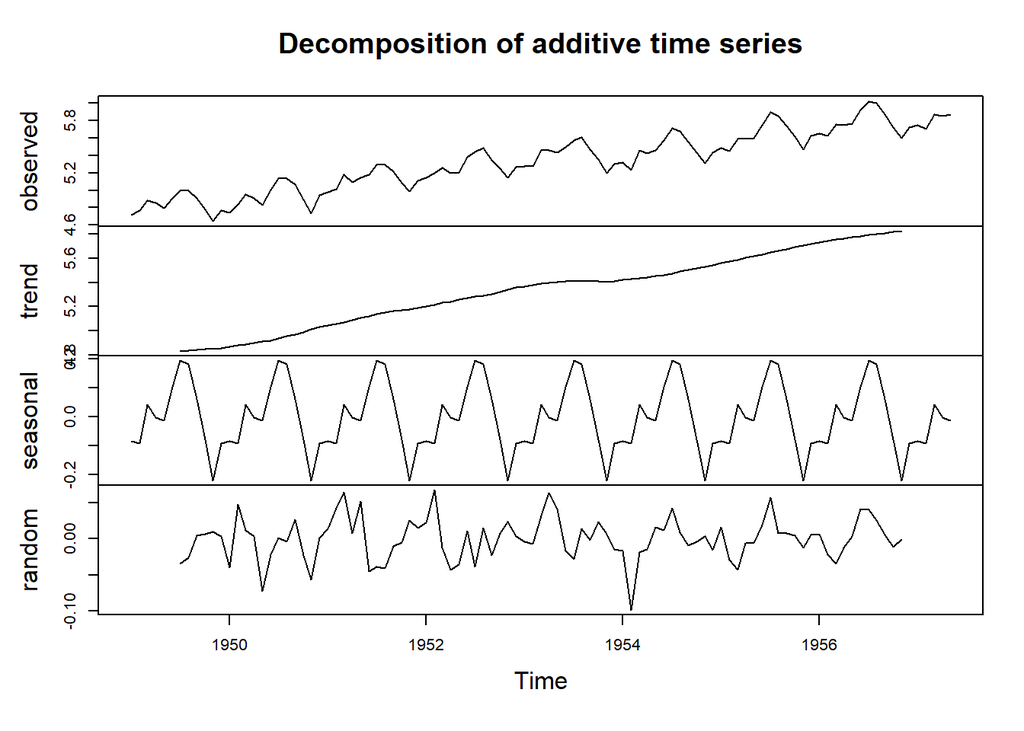

```r
plot(decompose(logTrain))
```

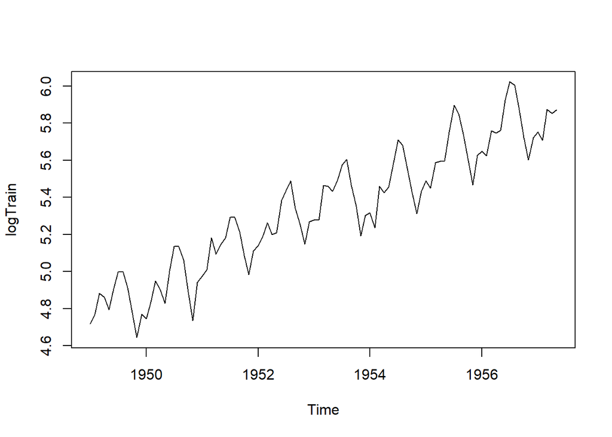

```r
plot(logTrain)
```

Al parecer se logró hacer constante la serie en varianza. Debemos verificar si es estacionaria en media. Si tiene raices unitarias podemos decir que no es estacionaria en media y hay que aplicar procesos de diferenciación.

```r
adfTest(train)
```

```
##
## Title:
##  Augmented Dickey-Fuller Test
##
## Test Results:
##   PARAMETER:
##     Lag Order: 1
##   STATISTIC:
##     Dickey-Fuller: 0.2037
##   P VALUE:
##     0.6781
##
## Description:
##  Wed Jul 29 19:37:41 2020 by user: flaquitqm
```

```r
unitrootTest(train)
```

```
##
## Title:
##  Augmented Dickey-Fuller Test
##
## Test Results:
##   PARAMETER:
##     Lag Order: 1
##   STATISTIC:
##     DF: 0.2037
##   P VALUE:
##     t: 0.7434
##     n: 0.7308
##
## Description:
##  Wed Jul 29 19:37:41 2020 by user: flaquitqm
```

```r
adfTest(diff(train))
```

```
##
## Title:
##  Augmented Dickey-Fuller Test
##
## Test Results:
##   PARAMETER:
##     Lag Order: 1
##   STATISTIC:
##     Dickey-Fuller: -7.466
##   P VALUE:
##     0.01
##
## Description:
##  Wed Jul 29 19:37:41 2020 by user: flaquitqm
```

```r
unitrootTest(diff(train))
```

```
##
## Title:
##  Augmented Dickey-Fuller Test
##
## Test Results:
##   PARAMETER:
##     Lag Order: 1
##   STATISTIC:
##     DF: -7.466
##   P VALUE:
##     t: 3.295e-16
##     n: 0.05517
##
## Description:
##  Wed Jul 29 19:37:41 2020 by user: flaquitqm
```

Como se puede ver el valor de p ahora sí está por debajo de 0.05 por lo que se puede descartar la hipótesis nula de que existan raices unitarias. Es necesaria solo una diferenciación.  
Es decir d = 1.  
Trataremos de identificar los parámetros p y q usando los gráficos de autocorrelación y autocorrelación parcial.

#### Función de autocorrelación:

*Funciones de autocorrelación teóricas*

| Modelo | FAC | FACP |
| --- | --- | --- |
| **MA(q)** | Se anula para j>q | Decrecimiento rápido. No se anula |
| **AR(p)** | Decrecimiento rápido. No se anula | Se anula para j>p |
| **ARMA(p,q)** | Decrecimiento rápido. No se anula | Decrecimiento rápido. No se anula |

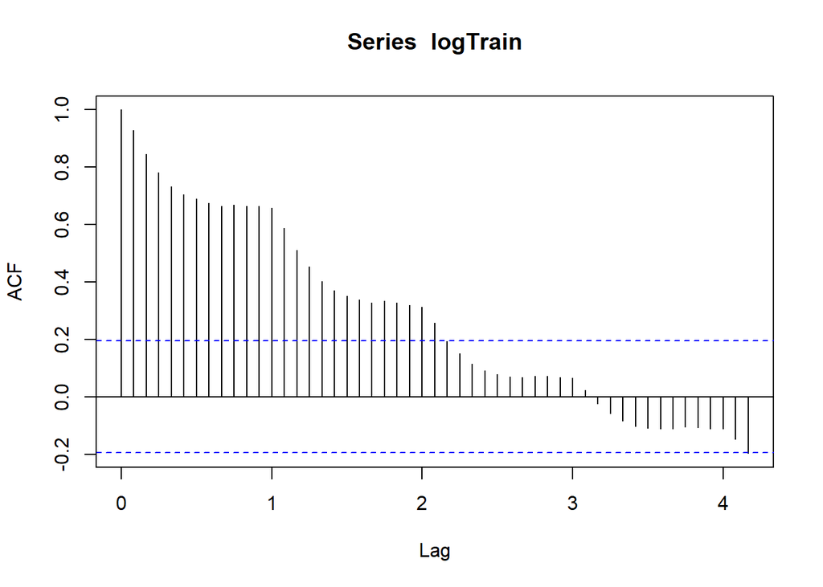

```r
acf(logTrain,50)
```

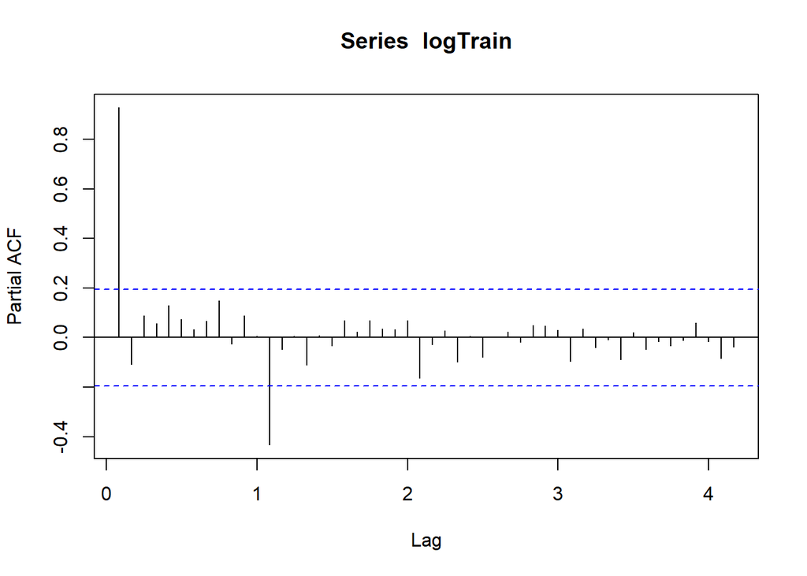

```r
pacf(logTrain,50)
```

Podemos ver que se anula después de un retardo por lo que podíamos plantear que el coeficiente p = 1.

Podríamos elaborar un modelo con los siguientes parámetros:

- p=1.
- q=2.
- d=1.

Es decir ARIMA(1,1,2).

Veamos si hay estacionalidad en la serie. Si volvemos a ver la descomposición de la serie en su componente estacional.

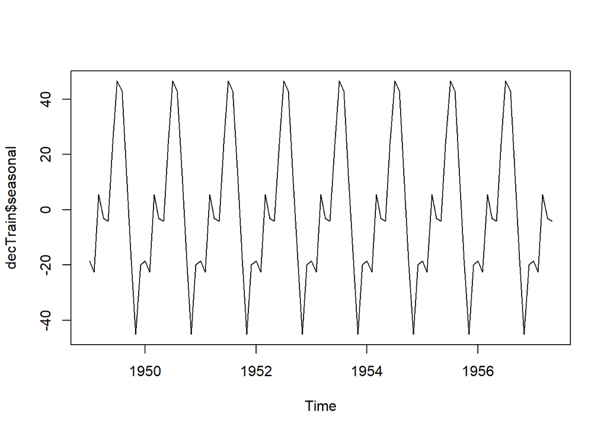

```r
decTrain <- decompose(train)
plot(decTrain$seasonal)
```

Al parecer sí existe estacionalidad en la serie. Para tener una idea de los parámetros estacionales veremos las funciones de autocorrelación y autocorrelación parcial con 36 resagos para ver en que momentos son los picos estacionales. Se usará la serie estacionarizada.

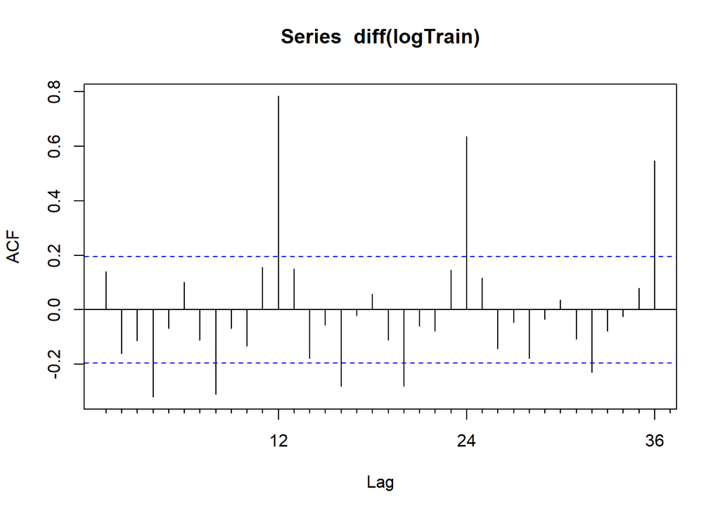

```r
Acf(diff(logTrain),36)
```

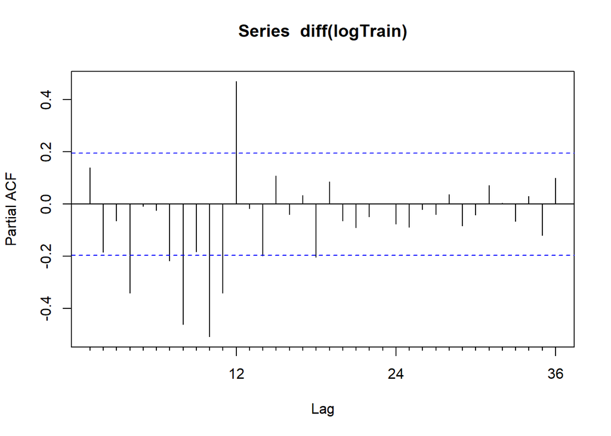

```r
Pacf(diff(logTrain),36)
```

Cómo podemos ver en la función de autocorrelación tenemos un decaimiento en los picos estacionales, 12, 24, 36, y en la función de autocorrelación parcial, un pico significativo en el retardo 12. Eso sugiere que los parámetros del componente estacional son P = 1, D = 1 (el período es de 12 meses por lo que se puede hacer una diferenciación estacional), y Q=0.

```r
fitArima <- arima(logTrain,order=c(1,1,2),seasonal = c(1,1,0))
```

R puede generar un modelo automático teniendo en cuenta los parámetros de la serie:

```r
fitAutoArima <- auto.arima(train)
```

1. Contrastes sobre los coeficientes:
- significatividad y raíces comunes.
2. Diagnóstico:
- Este análisis se basa habitualmente en los residuos que no deben estar correlacionados con el pasado: su correlograma no debe tener ninguna correlación significativamente distinta de cero.
3. Contrastes respecto a modelos alternativos

### Significación de los coeficientes:

Con esta prueba veremos que tan significativos son los coeficientes de los modelos.

```r
library(lmtest)
coeftest(fitArima)
```

```
##
## z test of coefficients:
##
##       Estimate Std. Error  z value  Pr(>|z|)
## ar1  -0.955756   0.075422 -12.6721 < 2.2e-16 ***
## ma1   0.535402   0.126633   4.2280 2.358e-05 ***
## ma2  -0.441295   0.105657  -4.1767 2.958e-05 ***
## sar1 -0.469558   0.091995  -5.1042 3.322e-07 ***
## ---
## Signif. codes:  0 '***' 0.001 '**' 0.01 '*' 0.05 '.' 0.1 ' ' 1
```

Cómo se puede obserevar todos los coeficientes son significativos. Veamos ahora el modelo generado de forma automática por R

```r
coeftest(fitAutoArima)
```

```
##
## z test of coefficients:
##
##      Estimate Std. Error z value Pr(>|z|)
## ar1  -0.24451    0.10384 -2.3546  0.01854 *
## sar1 -0.21238    0.10659 -1.9926  0.04631 *
## ---
## Signif. codes:  0 '***' 0.001 '**' 0.01 '*' 0.05 '.' 0.1 ' ' 1
```

También son significativos los coeficientes.  
Analicemos ahora los residuos de ambos modelos:

### Análisis de Residuales

Los residuales deben ser lo más parecidos posible a un ruido blanco. Esto es que sean aleatorios (no están correlacionados entre sí), y que estén distribuidos normalmente. Analizamos los residuos de nuestro modelo fitArima

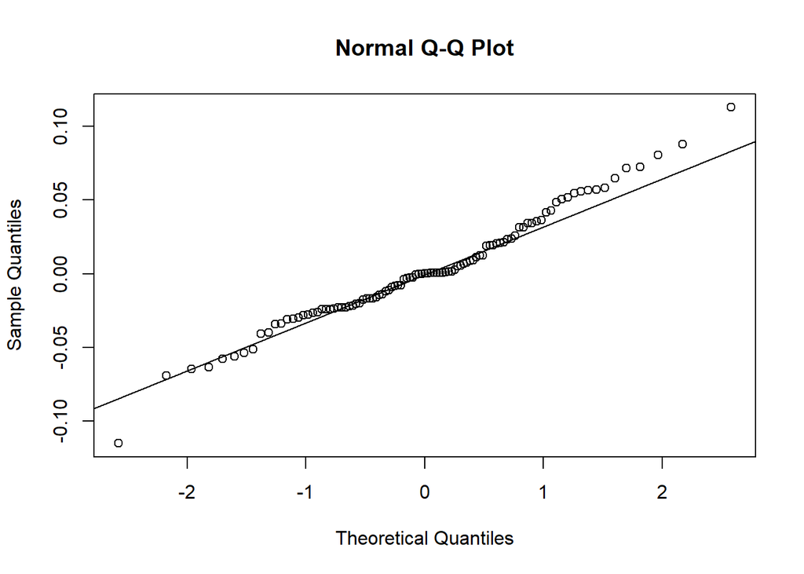

```r
qqnorm(fitArima$residuals)
qqline(fitArima$residuals)
```

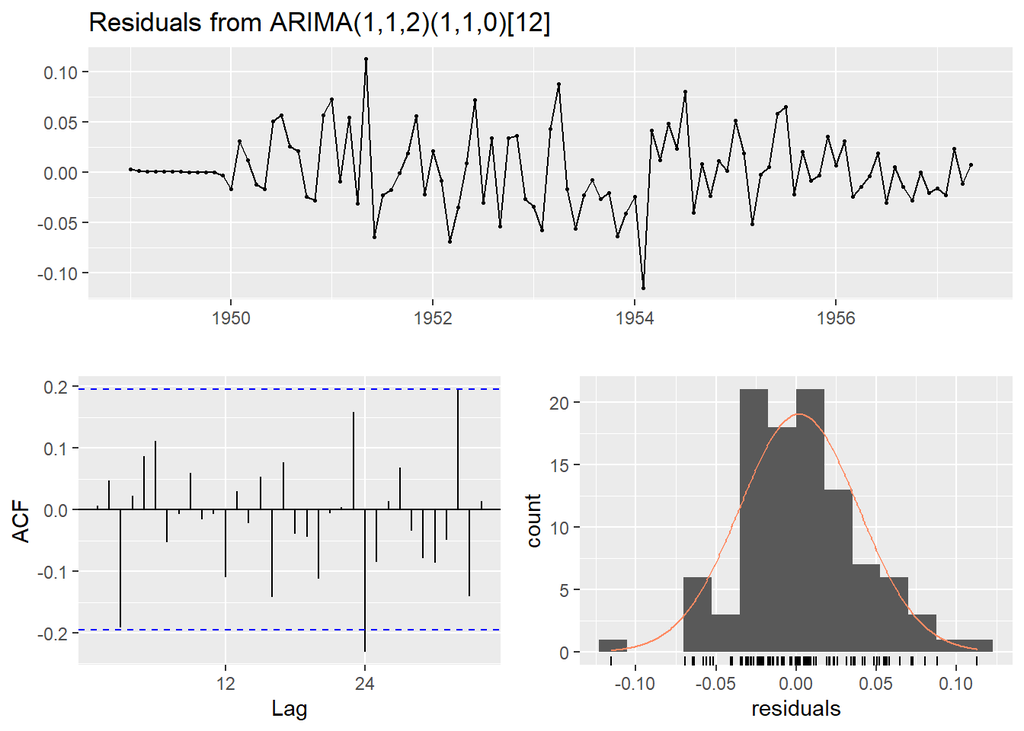

```
##
##  Ljung-Box test
##
## data:  Residuals from ARIMA(1,1,2)(1,1,0)[12]
## Q* = 14.312, df = 16, p-value = 0.5755
##
## Model df: 4.   Total lags used: 20
```

```r
checkresiduals(fitArima)
```

Analizando los residuos del modelo generado de forma automática por R tenemos los siguientes resultados:

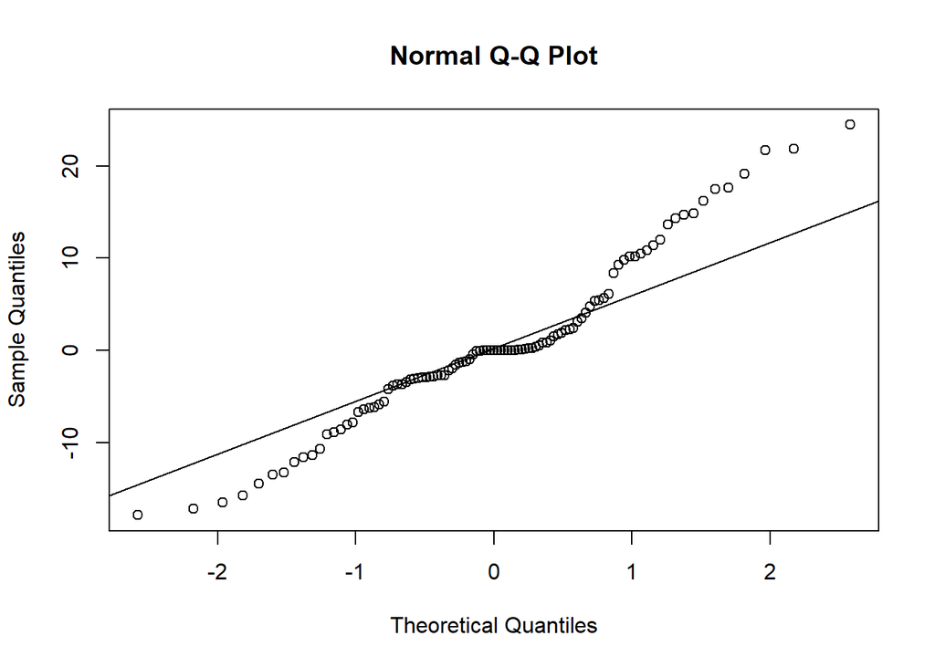

```r
qqnorm(fitAutoArima$residuals)
qqline(fitAutoArima$residuals)
```

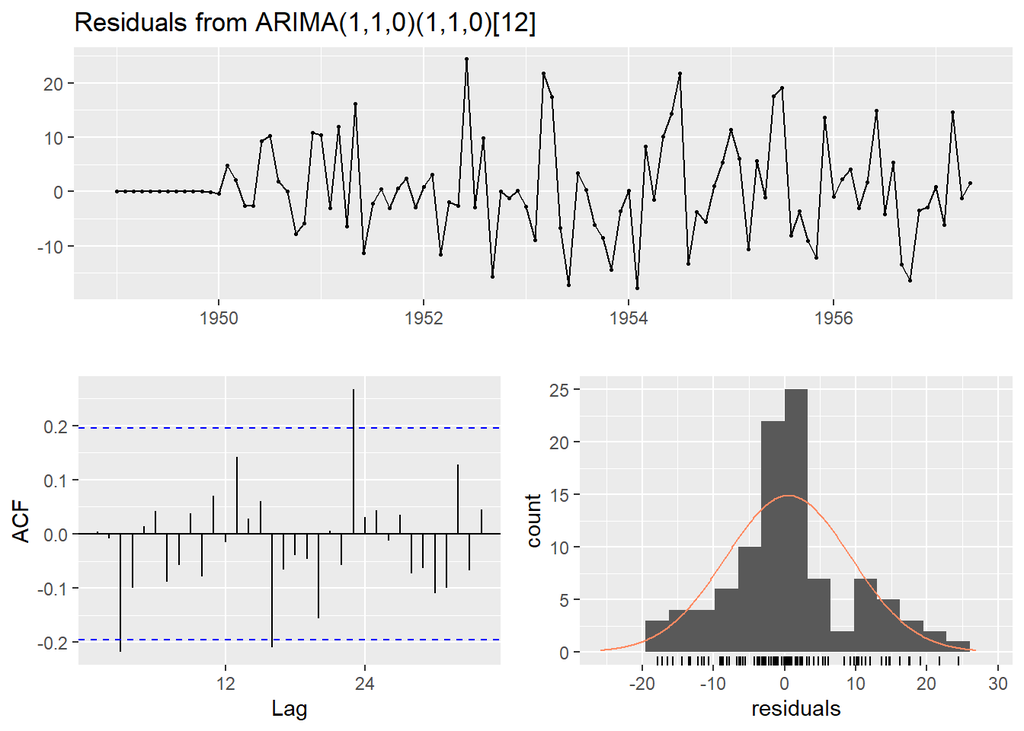

```
##
##  Ljung-Box test
##
## data:  Residuals from ARIMA(1,1,0)(1,1,0)[12]
## Q* = 21.393, df = 18, p-value = 0.2601
##
## Model df: 2.   Total lags used: 20
```

```r
checkresiduals(fitAutoArima)
```

Como podemos observar también es un buen modelo para predecir.

### Contrastes respecto a modelos alternativos.

En la práctica se utilizan dos de estos criterios:  
- [AIC (Akaike Information Criteria)](https://es.wikipedia.org/wiki/Criterio_de_informaci%C3%B3n_de_Akaike)  
- [BIC (Bayes Information Criteria)](https://en.wikipedia.org/wiki/Bayesian_information_criterion)

```r
AIC(fitArima,fitAutoArima)
```

```
##              df       AIC
## fitArima      5 -304.8899
## fitAutoArima  3  650.5536
```

```r
BIC(fitArima,fitAutoArima)
```

```
##              df       BIC
## fitArima      5 -292.5033
## fitAutoArima  3  657.9856
```

Segun los criterios de información podríamos decir que el modelo fitArima, debe ser mejor prediciendo, no obstante probaremos ambos.

## Predicción con el modelo generado

Una vez que tenemos seleccionado el modelo a usar, predeciremos con la función forecast, la misma cantidad de meses que hay en el conjunto de prueba y los compararemos con los valores reales del mismo.

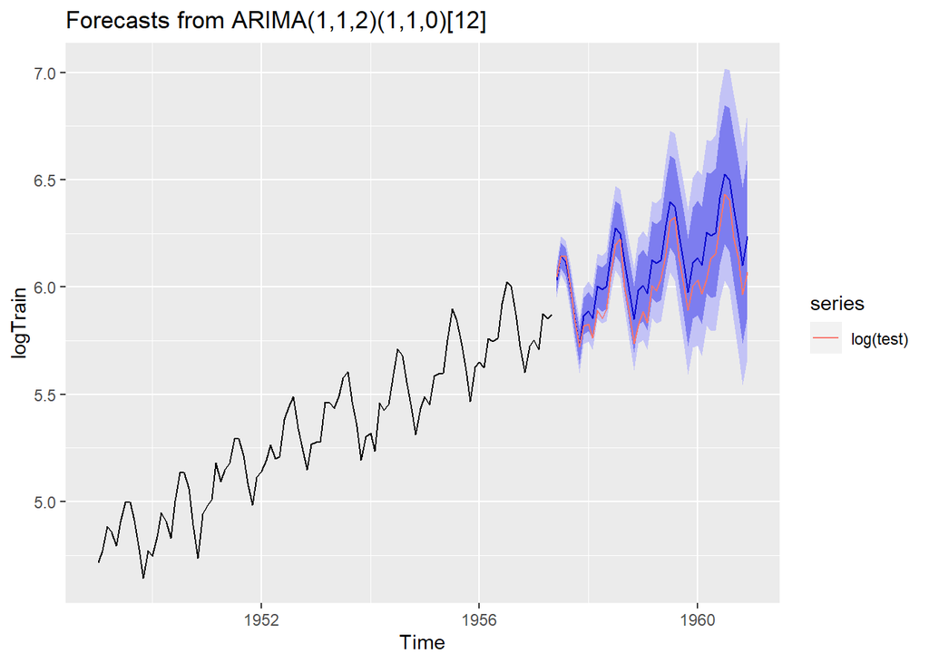

```r
fitArima %>%
  forecast(h) %>%
  autoplot() + autolayer(log(test))
```

Cómo se puede observar el modelo predice bastante bien, bastante acertado con respecto al conjunto de prueba.

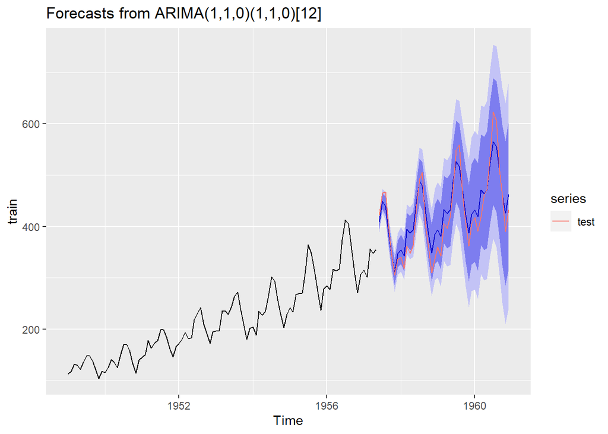

```r
fitAutoArima %>%
  forecast(h) %>%
  autoplot() + autolayer(test)
```

Cómo se puede ver este modelo tampoco es malo prediciendo, comparado con los datos reales.

# Otros algoritmos para predecir con series de tiempo.

## Prophet

[Prophet](https://facebook.github.io/prophet/) es un algoritmo creado por facebook para poder hacer pronósticos en series de tiempo, está disponible para R y para python. En R tanto el paquete como la biblioteca están bajo el nombre “prophet”.

```r
library(prophet)
library(zoo)
df<-data.frame(ds=as.Date(as.yearmon(time(train))),y=as.matrix(train) )
testdf<-data.frame(ds=as.Date(as.yearmon(time(test))),y=as.matrix(test) )
```

Así lucen los datos luego de transformarlos en el formato que necesita para predecir.

```r
head(df)
```

```
##           ds   y
## 1 1949-01-01 112
## 2 1949-02-01 118
## 3 1949-03-01 132
## 4 1949-04-01 129
## 5 1949-05-01 121
## 6 1949-06-01 135
```

Luego elaboramos el modelo:

```r
fitProphet<-prophet(df,yearly.seasonality = T,weekly.seasonality = T)
```

```
## Disabling daily seasonality. Run prophet with daily.seasonality=TRUE to override this.
```

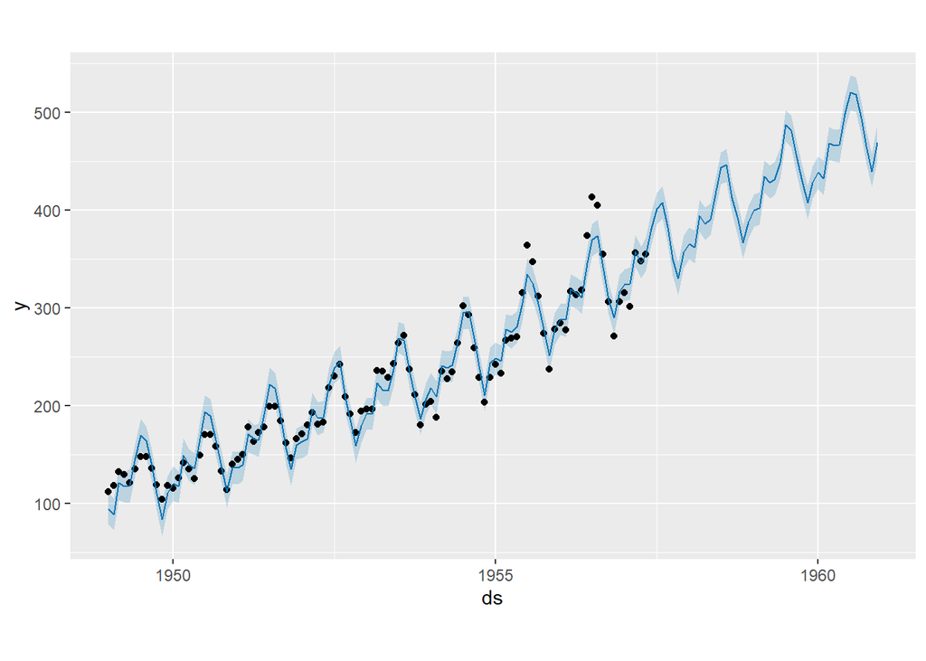

```r
future <- make_future_dataframe(fitProphet,periods = h,freq = "month", include_history = T)
p <- predict(fitProphet,future)
p<-p[,c("ds","yhat","yhat_lower","yhat_upper")]
plot(fitProphet,p)
```

Veamos que tanto se acerca la predicción a los datos reales, en el siguiente gráfico. Los datos del conjunto de prueba se representan en rojo mientras los datos de la predicción se representan en azul.

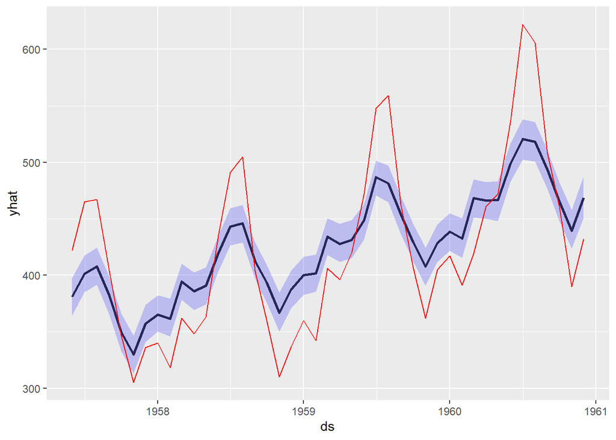

```r
pred<-tail(p,h)
pred$y<-testdf$y


ggplot(pred, aes(x=ds, y=yhat)) +
   geom_line(size=1, alpha=0.8) +
   geom_ribbon(aes(ymin=yhat_lower, ymax=yhat_upper), fill="blue", alpha=0.2) +
   geom_line(data=pred, aes(x=ds, y=y),color="red")
```